# Test Script

2023-09-16

# Loading and installing MSGene

- First load from Github

```r
devtools::install_github("surbut/MSGene")
```

```r
require(MSGene)
```

## Now load our data

First, we load our sample data frame. You will need to request a data frame with the following columns. We cannot share our UKB data but you can assembley your own variables using the [ukbpheno](https://github.com/niekverw/ukbpheno/blob/master/inst/extdata/definitions_cardiometabolic_traits.tsv) packages

```
FALSE     cad.prs f.31.0.0 Cad_0_censor_age Ht_0_censor_age Dm_0_censor_age
FALSE 1 -0.232384        1         82.29158        82.29158        82.29158
FALSE 2  0.419198        1         57.54141        57.54141        57.54141
FALSE 3  0.640905        0         81.37440        81.37440        81.37440
FALSE 4 -0.559320        1         76.21903        76.21903        76.21903
FALSE 5 -0.373879        0         66.29158        61.52225        66.29158
FALSE 6  1.131000        0         61.12252        61.12252        61.12252
FALSE   HyperLip_0_censor_age Cad_0_Any Dm_0_Any Ht_0_Any HyperLip_0_Any
FALSE 1              69.54689         1        1        1              2
FALSE 2              57.54141         1        1        1              1
FALSE 3              81.37440         1        1        1              1
FALSE 4              76.21903         1        1        1              1
FALSE 5              66.29158         1        1        2              1
FALSE 6              61.22108         1        1        1              2
FALSE   Death_censor_Any Death_Censor_Age antihtn    statin_age htn_age smoke statin
FALSE 1                1         82.39158       0 69.35797 days NA days     0      1
FALSE 2                1         57.64141       0       NA days NA days     1      0
FALSE 3                1         81.47440       0       NA days NA days     0      0
FALSE 4                2         76.21903       0       NA days NA days     0      0
FALSE 5                1         66.39158       0       NA days NA days     0      0
FALSE 6                1         61.22252       0       NA days NA days     0      0
```

## Set a training set

- Now, we select a portion of the data for training

```r
train = df2[1:(nrow(df2) * 0.8), ]
```

## Parameter choice

- Here we choose the ages we will consider and the states we will move through.

```r
ages = c(40:80)
nstates = c("Health", "Ht", "HyperLip", "Dm", "Cad", "death", "Ht&HyperLip", "HyperLip&Dm",
    "Ht&Dm", "Ht&HyperLip&Dm")
```

### Fit our model

Now we’re ready to fit our model! Sit tight, this step takes between 60-90 seconds … but it’s worht it.

```r
modelfit = fitfunc2(df_frame = data.table::data.table(train), ages = ages, nstates = nstates,
    mode = "binomial", covariates = "cad.prs+f.31.0.0+smoke+antihtn_now+statin_now")
```

### Look at all that we’ve produced!

```r
attributes(modelfit)
```

```
FALSE $names
FALSE [1] "events"       "rates"        "AR"           "model_list"   "yearsinstate"
```

You can see in this array we have the number of events, the absolute rate per year per transition, the number at risk per year and per transition, and the list of models over years and states.

### Extract coefficients for health–>CAD transition

To compute our risk calculations, we need to extract the unsmoothed coefficients, we will feed through a smoother, and then use these coefficients to compute our product.

```r
a = coefplotsmooth2(ages = ages, start = nstates[1], stop = "Cad", modelfit = modelfit,
    window_width = 20, span = 0.75, degree = 2)
healthy_coefs = a$custom_smooth
```

## We want to create a sample matrix to test.

```r
intercept = 1
cad.prs = c(-2, -1, 0, 1, 2)
sex = c(0, 1)
smoke = c(0, 1)
antihtn_now = c(0, 1)
statin_now = c(0, 1)
atrisk = expand.grid(intercept, cad.prs, sex, smoke, antihtn_now, statin_now)
head(atrisk)
```

```
FALSE   Var1 Var2 Var3 Var4 Var5 Var6
FALSE 1    1   -2    0    0    0    0
FALSE 2    1   -1    0    0    0    0
FALSE 3    1    0    0    0    0    0
FALSE 4    1    1    0    0    0    0
FALSE 5    1    2    0    0    0    0
FALSE 6    1   -2    1    0    0    0
```

## Compute things …

We now want to extract some useful quanitites. For example, for the 80 sample individuals in our grid, we can extract: 1) remaining lifetime risk matrix starting from each 40 for all 80 individuals in the profile. Recall that this is the *complement of the product of the annual surivivals*

```r
mso = compute_prediction_product_matrix(coefmat = healthy_coefs, atrisk = atrisk,
    agepredinterval = c(40:80))

mso$PredictedIntervalrisk
```

```
FALSE  [1] 0.03192629 0.04465484 0.06269812 0.08832705 0.12471401 0.07040536
FALSE  [7] 0.10017962 0.14279301 0.20327720 0.28753596 0.04446752 0.06189578
FALSE [13] 0.08643123 0.12097875 0.16945368 0.09644349 0.13631588 0.19263559
FALSE [19] 0.27100501 0.37682262 0.06618678 0.09468548 0.13575778 0.19451719
FALSE [25] 0.27711680 0.15938245 0.22977648 0.32787571 0.45789158 0.61546142
FALSE [31] 0.09052301 0.12876386 0.18324904 0.25981812 0.36436911 0.21360545
FALSE [37] 0.30411651 0.42560725 0.57671278 0.74113358 0.10161686 0.15015554
FALSE [43] 0.22095205 0.32122287 0.45565598 0.27222142 0.39267748 0.54653329
FALSE [49] 0.71812356 0.87045410 0.13644882 0.20034569 0.29166523 0.41639477
FALSE [55] 0.57326393 0.35525504 0.50014094 0.66970447 0.83250520 0.94503185
FALSE [61] 0.26587867 0.38554755 0.53962731 0.71292784 0.86793832 0.64101762
FALSE [67] 0.80953721 0.93268088 0.98761697 0.99916594 0.34828618 0.49328304
FALSE [73] 0.66438317 0.82981564 0.94449248 0.76355011 0.90463696 0.97848904
FALSE [79] 0.99804524 0.99995276
```

We can also extract the predicted risk over the same interval, for someone on treatment, here with statins with a relative risk reduction of 0.20.

- remaining lifetime risk matrix under treatment starting from 40

```r
mso$Hazard_treated
```

```
FALSE  [1] 0.02561954 0.03587885 0.05046749 0.07128383 0.10103578 0.05671728
FALSE  [7] 0.08095206 0.11591263 0.16612774 0.23735575 0.03572664 0.04981581
FALSE [13] 0.06973703 0.09796544 0.13794346 0.07789964 0.11057253 0.15723309
FALSE [19] 0.22324652 0.31466396 0.05329668 0.07646974 0.11011995 0.15881342
FALSE [25] 0.22846716 0.12962008 0.18837022 0.27204767 0.38680353 0.53360961
FALSE [31] 0.07307436 0.10436502 0.14941842 0.21374955 0.30376729 0.17478153
FALSE [37] 0.25157149 0.35784822 0.49656547 0.65956526 0.08213080 0.12199436
FALSE [43] 0.18094985 0.26629447 0.38476426 0.22429360 0.32860836 0.46808276
FALSE [49] 0.63555689 0.80313069 0.11069407 0.16368816 0.24090098 0.34963910
FALSE [55] 0.49326840 0.29581212 0.42519003 0.58668547 0.75883471 0.89983703
FALSE [61] 0.21890029 0.32232984 0.46164552 0.63023762 0.80011534 0.55829698
FALSE [67] 0.73287215 0.88240895 0.96866027 0.99604238 0.28974489 0.41891468
FALSE [73] 0.58139859 0.75576202 0.89903655 0.68298712 0.84537666 0.95187060
FALSE [79] 0.99243242 0.99953557
```

You can also make cool plots examining the proportional occupancy of each state:

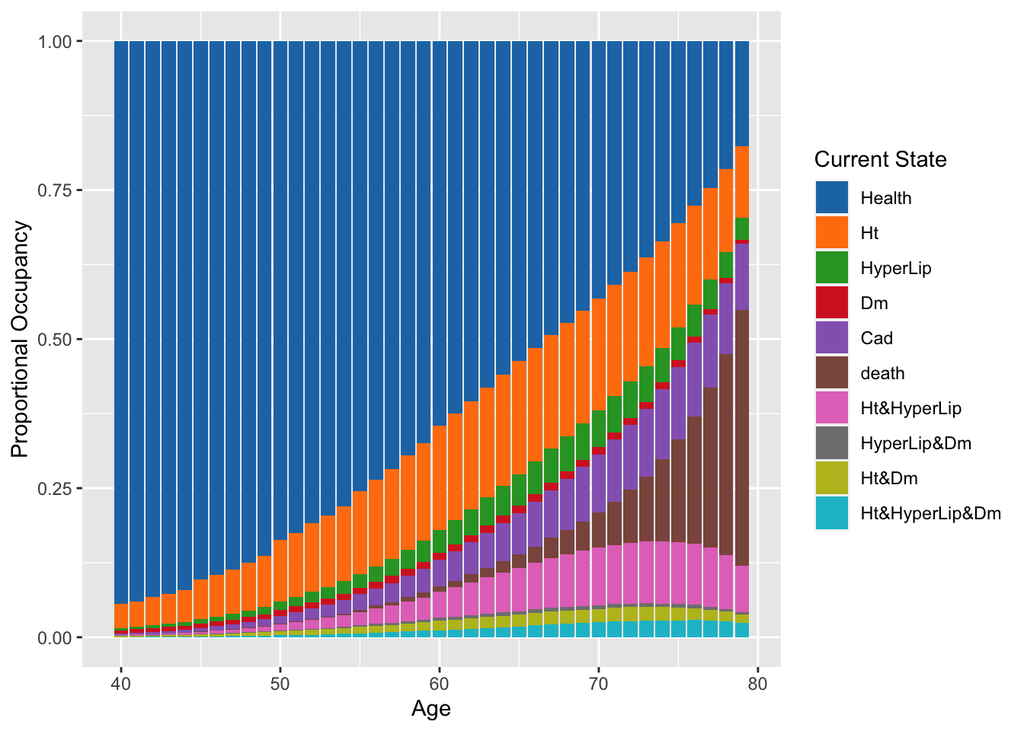